# Midterm_Multivariate

Hwang Seong-Yun

2020 10 28

## I. 다음 자료는 암모니아의 산화공정에 관한 세 변수에 대한 자료로 21개의 관측치가 있으며 변수 x1은 공정률, 변수 x2는 온도, 변수 x3는 산농축정도를 나타내는 퇴비자료이다(Rousseeuw and Leroy, 1987, p.76). 다음 물음에 답하시오.

```r
library(tidyverse)
ex1 <- tibble(x1=c(80,80,75,62,62,62,62,62,58,58,58,58,58,58,50,50,50,50,50,56,70),x2=c(27,27,25,24,22,23,24,24,23,18,18,17,18,19,18,18,19,19,20,20,20),x3=c(89,88,90,87,87,87,93,93,87,80,89,88,82,93,89,86,72,79,80,82,91))
ex1
```

```
## # A tibble: 21 x 3
##       x1    x2    x3
##    <dbl> <dbl> <dbl>
##  1    80    27    89
##  2    80    27    88
##  3    75    25    90
##  4    62    24    87
##  5    62    22    87
##  6    62    23    87
##  7    62    24    93
##  8    62    24    93
##  9    58    23    87
## 10    58    18    80
## # ... with 11 more rows
```

### (1) 표본평균벡터, 표본공분산행렬을 구하시오.

```r
colMeans(ex1) # sample mean vector
```

```
##       x1       x2       x3
## 60.42857 21.09524 86.28571
```

```r
cov(ex1) # sample covariance matrix
```

```
##          x1        x2        x3
## x1 84.05714 22.657143 24.571429
## x2 22.65714  9.990476  6.621429
## x3 24.57143  6.621429 28.714286
```

### (2) (1)에서 구한 표본공분산행렬을 대응하는 표본상관행렬로 변환하시오.

```r
cor(ex1) # sample correlation matrix
```

```
##           x1        x2        x3
## x1 1.0000000 0.7818523 0.5001429
## x2 0.7818523 1.0000000 0.3909395
## x3 0.5001429 0.3909395 1.0000000
```

### (3) 각 변수의 정규확률그림과 카이제곱그림을 검토하시오.

### (4) 다변량정규분포를 따르는가?

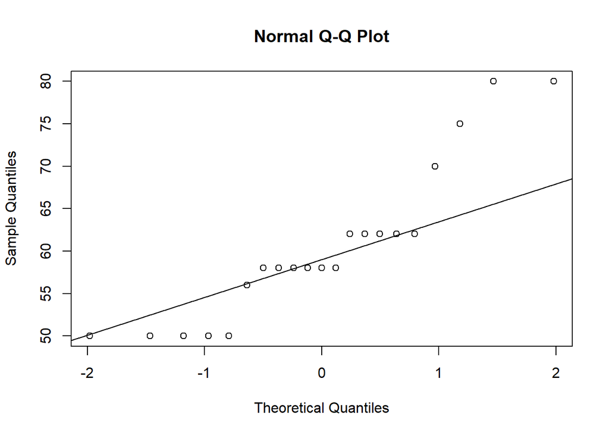

```r
# variable x1
qqnorm(ex1$x1) ; qqline(ex1$x1)
```

```r
shapiro.test(ex1$x1)
```

```
##
##  Shapiro-Wilk normality test
##
## data:  ex1$x1
## W = 0.86115, p-value = 0.006651
```

#### 변수 x1은 정규성이 의심됨. (p-value = 0.0067 < 0.05)

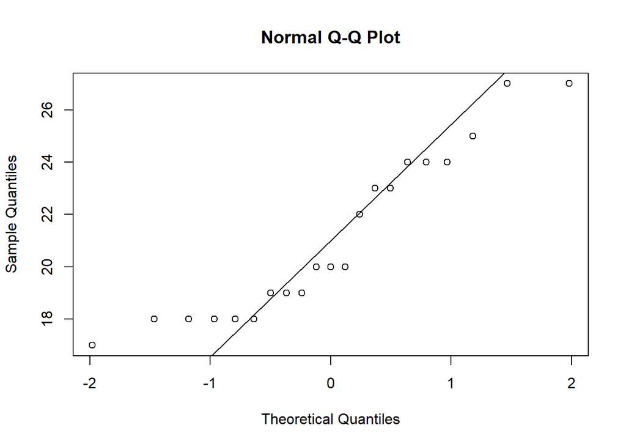

```r
# variable x2
qqnorm(ex1$x2) ; qqline(ex1$x2)
```

```r
shapiro.test(ex1$x2)
```

```
##
##  Shapiro-Wilk normality test
##
## data:  ex1$x2
## W = 0.89502, p-value = 0.02805
```

#### 변수 x2는 정규성이 의심됨. (p-value = 0.0281 < 0.05)

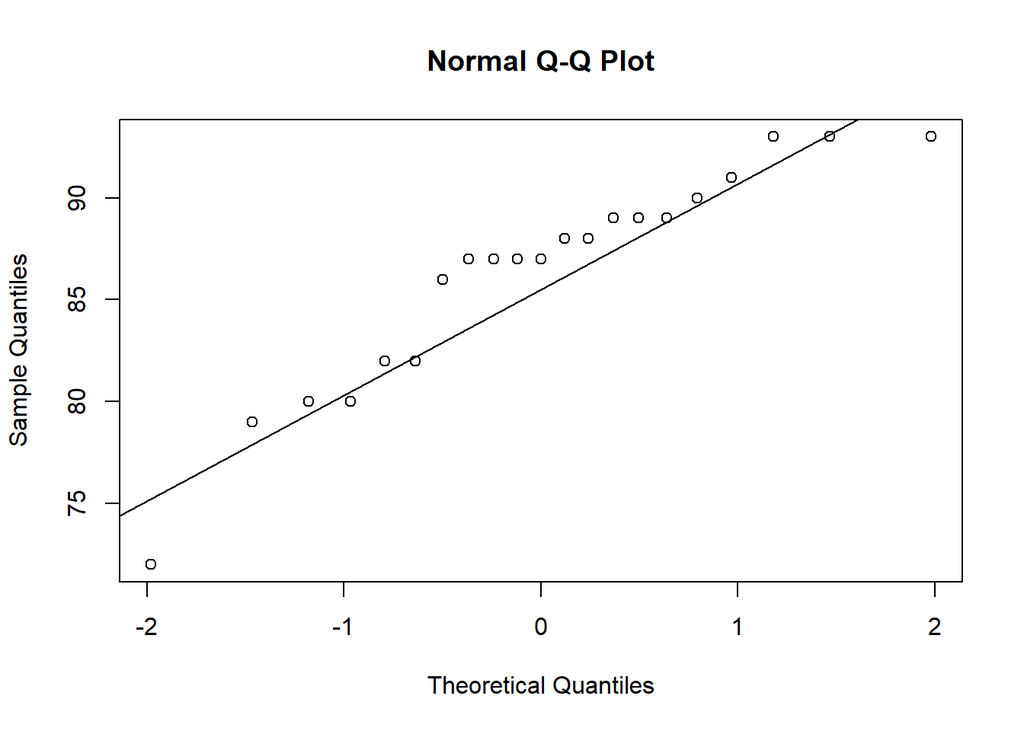

```r
# variable x3
qqnorm(ex1$x3) ; qqline(ex1$x3)
```

```r
shapiro.test(ex1$x3)
```

```
##
##  Shapiro-Wilk normality test
##
## data:  ex1$x3
## W = 0.90712, p-value = 0.04818
```

#### 변수 x3는 정규성이 의심됨. (p-value = 0.0481 < 0.05)

```r
library(mvoutlier)
```

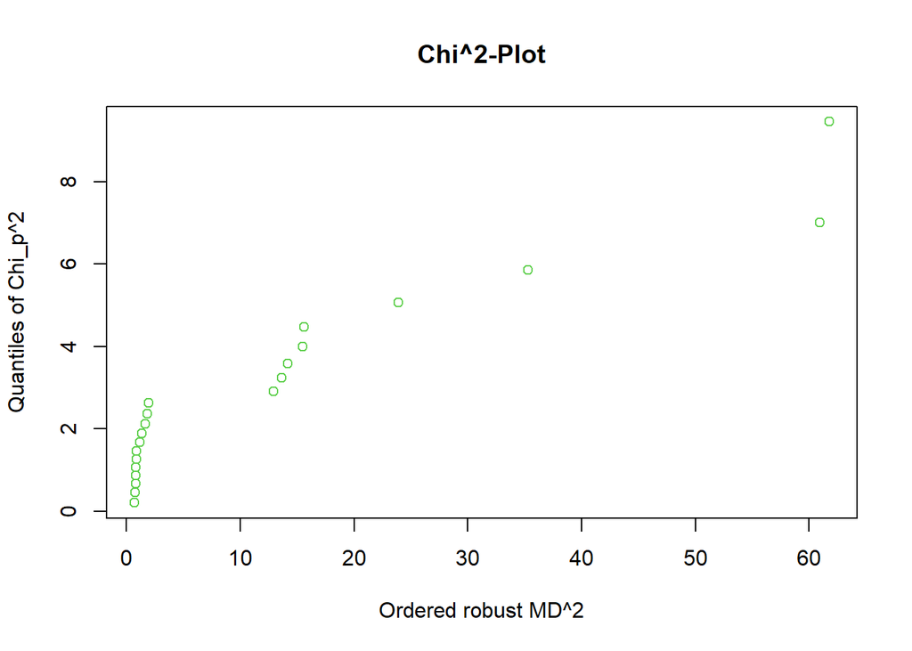

```
## Remove outliers with left-click, stop with right-click on plotting device
```

```r
chisq.plot(ex1)
```

#### 카이제곱그림을 확인한 결과, 다변량 정규분포를 따르지 않는 것으로 판단됨.

### (5) 다변량 정규분포로 변환을 하여 정규성이 향상되었는지 확인하시오.

```r
library(MASS)
library(rcompanion)
library(car)
```

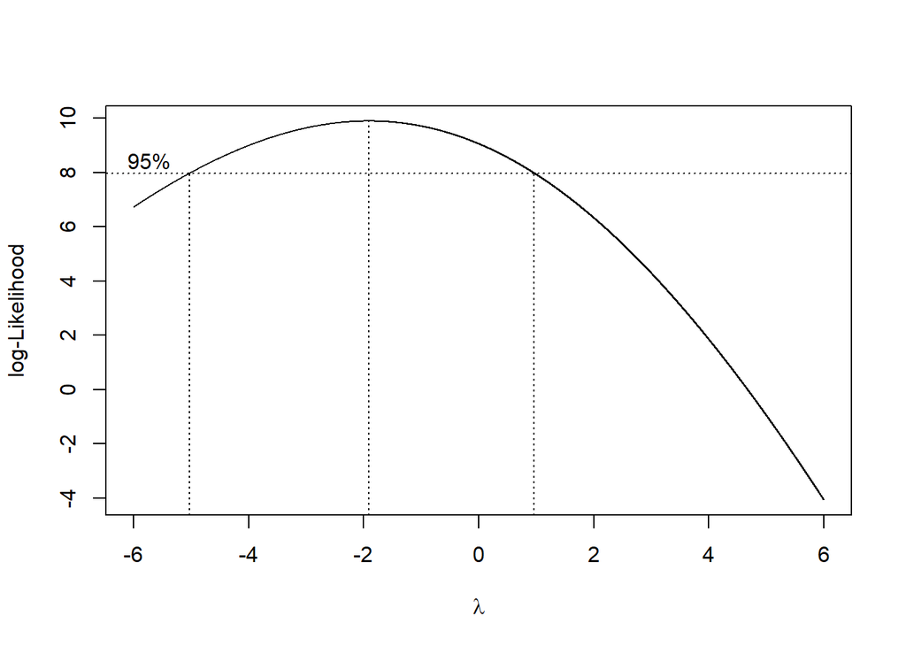

```r
## 변수 x1에 대한 변환
Box <- boxcox(ex1$x1~1, lambda=seq(-6,6,0.001))
```

```r
Cox <- data.frame(Box$x, Box$y) # x : lambda의 값, y : log-likelihood의 값
Cox2 <- Cox[with(Cox, order(-Cox$Box.y)),] # minus log-likelihood의 크기순으로 정렬
Cox2[1,] # minus log-likelihood의 값이 최대가 되는 경우
```

```
##      Box.x    Box.y
## 4091 -1.91 9.894492
```

```r
(lambda <- Cox2[1, "Box.x"]) # minus log-likelihood의 값이 최대가 되는 경우의 lambda 값
```

```
## [1] -1.91
```

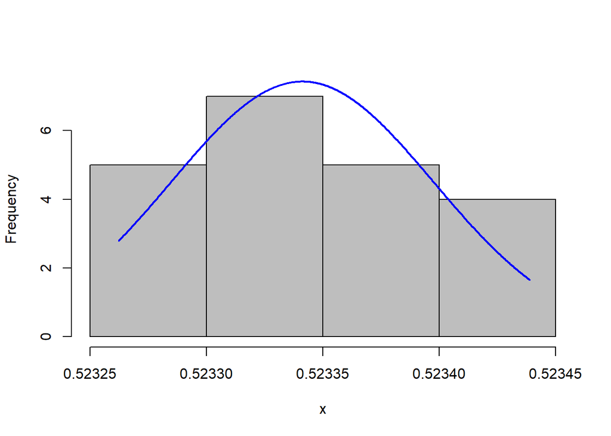

```r
x1_trans <- (ex1$x1^lambda - 1)/lambda # power transformation
plotNormalHistogram(x1_trans)
```

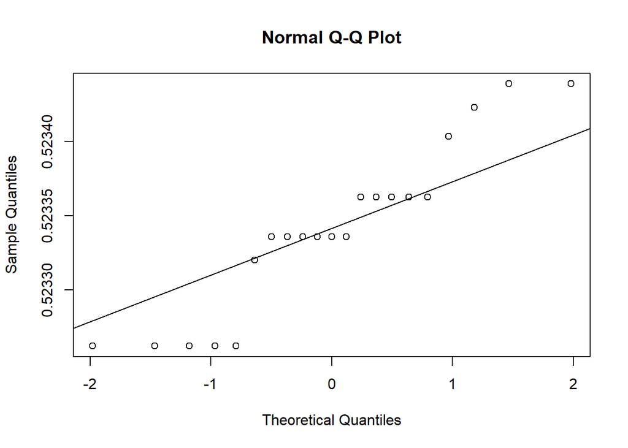

```r
qqnorm(x1_trans) ; qqline(x1_trans)
```

```r
shapiro.test(x1_trans)
```

```
##
##  Shapiro-Wilk normality test
##
## data:  x1_trans
## W = 0.89876, p-value = 0.03311
```

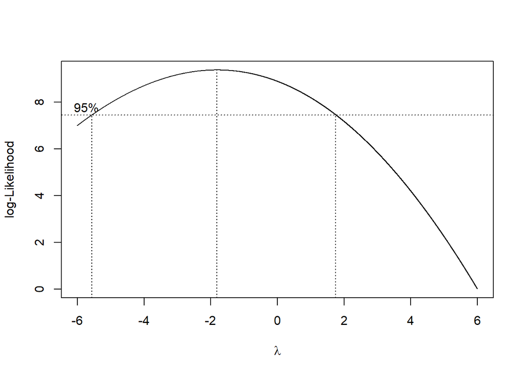

```r
## 변수 x2에 대한 변환
Box <- boxcox(ex1$x2~1, lambda=seq(-6,6,0.001))
```

```r
Cox <- data.frame(Box$x, Box$y) # x : lambda의 값, y : log-likelihood의 값
Cox2 <- Cox[with(Cox, order(-Cox$Box.y)),] # minus log-likelihood의 크기순으로 정렬
Cox2[1,] # minus log-likelihood의 값이 최대가 되는 경우
```

```
##      Box.x    Box.y
## 4191 -1.81 9.376318
```

```r
(lambda <- Cox2[1, "Box.x"]) # minus log-likelihood의 값이 최대가 되는 경우의 lambda 값
```

```
## [1] -1.81
```

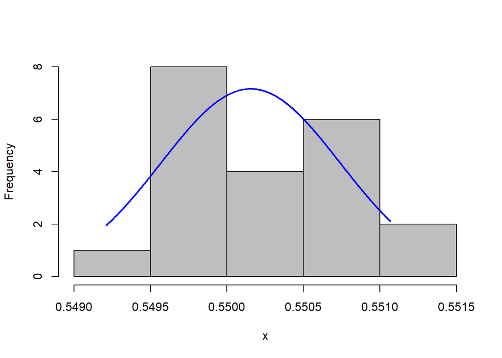

```r
x2_trans <- (ex1$x2^lambda - 1)/lambda # power transformation
plotNormalHistogram(x2_trans)
```

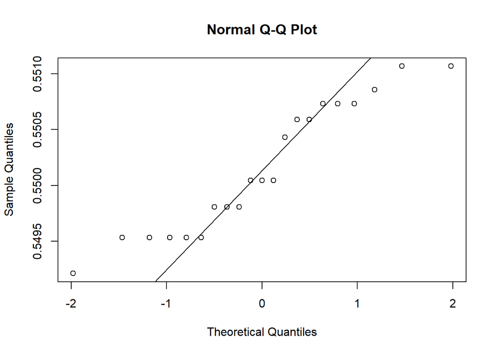

```r
qqnorm(x2_trans) ; qqline(x2_trans)
```

```r
shapiro.test(x2_trans)
```

```
##
##  Shapiro-Wilk normality test
##
## data:  x2_trans
## W = 0.91498, p-value = 0.06891
```

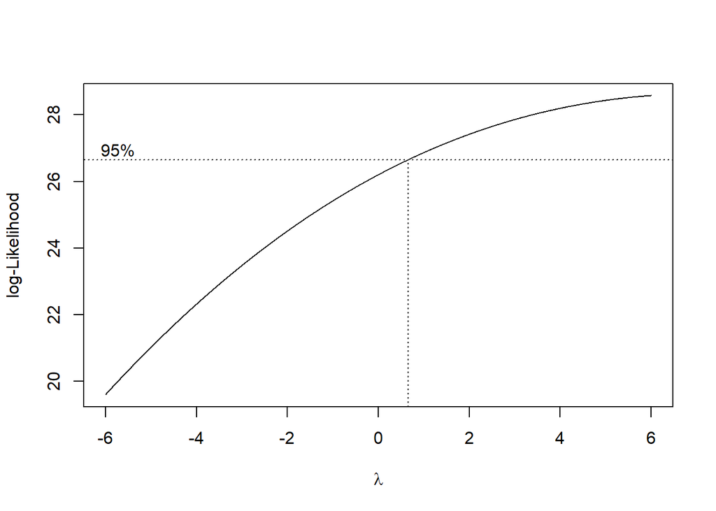

```r
## 변수 x3에 대한 변환
Box <- boxcox(ex1$x3~1, lambda=seq(-6,6,0.001))
```

```r
Cox <- data.frame(Box$x, Box$y) # x : lambda의 값, y : log-likelihood의 값
Cox2 <- Cox[with(Cox, order(-Cox$Box.y)),] # minus log-likelihood의 크기순으로 정렬
Cox2[1,] # minus log-likelihood의 값이 최대가 되는 경우
```

```
##       Box.x    Box.y
## 12001     6 28.57164
```

```r
(lambda <- Cox2[1, "Box.x"]) # minus log-likelihood의 값이 최대가 되는 경우의 lambda 값
```

```
## [1] 6
```

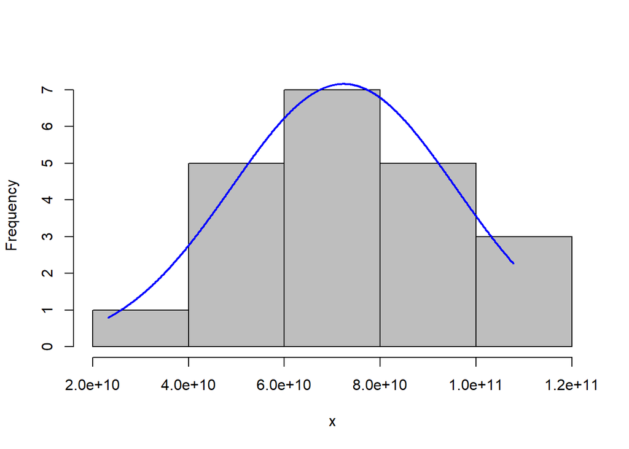

```r
x3_trans <- (ex1$x3^lambda - 1)/lambda # power transformation
plotNormalHistogram(x3_trans)
```

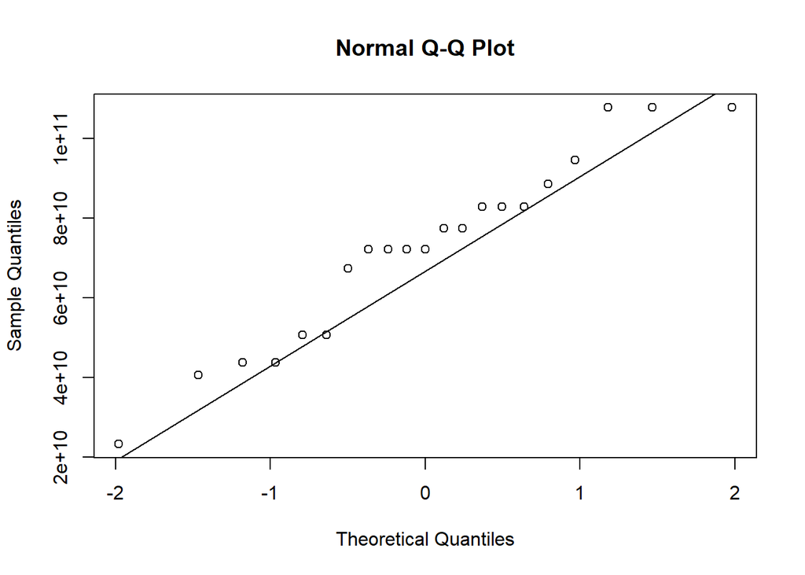

```r
qqnorm(x3_trans) ; qqline(x3_trans)
```

```r
shapiro.test(x3_trans)
```

```
##
##  Shapiro-Wilk normality test
##
## data:  x3_trans
## W = 0.95046, p-value = 0.3475
```

#### 변환결과, 변수 x1을 제외하고는 어느정도 정규성을 만족하는 것으로 판단됨.

```r
(a <- powerTransform(cbind(ex1$x1,ex1$x2,ex1$x3)~1))
```

```
## Estimated transformation parameters
##         Y1         Y2         Y3
## -1.3855052  0.0969406  5.8175407
```

```r
summary(powerTransform(cbind(ex1$x1,ex1$x2,ex1$x3)~1))
```

```
## bcPower Transformations to Multinormality
##    Est Power Rounded Pwr Wald Lwr Bnd Wald Upr Bnd
## Y1   -1.3855           1      -3.9034       1.1324
## Y2    0.0969           1      -3.3312       3.5251
## Y3    5.8175           1      -0.4771      12.1122
##
## Likelihood ratio test that transformation parameters are equal to 0
##  (all log transformations)
##                                LRT df    pval
## LR test, lambda = (0 0 0) 5.269944  3 0.15306
##
## Likelihood ratio test that no transformations are needed
##                                LRT df     pval
## LR test, lambda = (1 1 1) 6.394503  3 0.093917
```

```r
x1_trans1 <- (ex1$x1^(-1.3855052) - 1)/(-1.3855052)
x2_trans1 <- (ex1$x2^(0.0969406) - 1)/(0.0969406)
x3_trans1 <- (ex1$x3^(5.8175407) - 1)/(5.8175407)
```

## II. 다음 자료는 n=25 인 가족의 표본으로부터 성인인 첫째 아들과 둘째 아들의 머리의 길이(length)와 너비(breath)를 측정한 자료이다.

```r
ex2 <- tibble(length=c(191,195,181,183,176,208,189,197,188,192,179,183,174,190,188,163,195,186,181,175,192,174,176,197,190,179,201,185,188,171,192,190,189,197,187,186,174,185,195,187,161,183,173,182,165,185,178,176,200,187),breath=c(155,149,148,153,144,157,150,159,152,150,158,147,150,159,151,137,155,153,145,140,154,143,139,167,163,145,152,149,149,142,152,149,152,159,151,148,147,152,157,158,130,158,148,146,137,152,147,143,158,150),group=c(rep("first",25),rep("second",25)))
ex2
```

```
## # A tibble: 50 x 3
##    length breath group
##     <dbl>  <dbl> <chr>
##  1    191    155 first
##  2    195    149 first
##  3    181    148 first
##  4    183    153 first
##  5    176    144 first
##  6    208    157 first
##  7    189    150 first
##  8    197    159 first
##  9    188    152 first
## 10    192    150 first
## # ... with 40 more rows
```

### (1) 첫째와 둘째 아들의 머리 길이에 대한 모평균 벡터가 mu^T = [182,182]^T 인지를 검정하시오.

```r
library(ICSNP)
HotellingsT2(cbind(ex2$length[ex2$group=="first"],ex2$length[ex2$group=="second"]), mu=c(182,182))
```

```
##
##  Hotelling's one sample T2-test
##
## data:  cbind(ex2$length[ex2$group == "first"], ex2$length[ex2$group ==     "second"])
## T.2 = 1.9253, df1 = 2, df2 = 23, p-value = 0.1686
## alternative hypothesis: true location is not equal to c(182,182)
```

#### 검정결과 p-value의 값이 0.1686으로 유의수준 0.05보다 매우 크게 산출되었다. 따라서 H0를 기각하지 못하게 되고, 첫째와 둘째 아들의 머리 길이와 대한 모평균 벡터는 mu^T = [182,182]^T 라고 결론내린다.

### (2) 첫째 아들과 둘째 아들의 머리의 길이와 너비의 모평균 벡터가 동일한지를 검정하시오.

#### 첫째 아들과 둘째 아들은 독립된 집단으로 보는 것이 바람직하므로 다음과 같이 검정을 실시한다.

```r
library(Hotelling)
fit <- hotelling.test(.~group, data=ex2)
fit
```

```
## Test stat:  0.4411
## Numerator df:  2
## Denominator df:  47
## P-value:  0.646
```

### (1) 세 종류의 공분산 행렬이 동일한지를 검정하시오.

```r
data(iris)
force(iris)
```

[output not shown]

[output cut: 136 more lines]

```r
library(biotools)
boxM(cbind(iris$Sepal.Length, iris$Sepal.Width, iris$Petal.Length, iris$Petal.Width) , iris$Species)
```

```
##
##  Box's M-test for Homogeneity of Covariance Matrices
##
## data:  cbind(iris$Sepal.Length, iris$Sepal.Width, iris$Petal.Length,     iris$Petal.Width)
## Chi-Sq (approx.) = 140.94, df = 20, p-value < 2.2e-16
```

#### 검정결과, p-value의 값이 거의 0에 가깝게 산출되었다. 따라서 Species에 따른 3종류의 공분산행렬은 동일하지 않다고 결론내린다.

### (2) 3가지 붓꽃 종류에 대해 평균벡터가 동일한지를 검정하시오.

#### Species에 따른 3종류의 공분산행렬이 동일하다고 가정하고 검정을 실시하면 다음과 같다.

```r
fit1 <- manova(cbind(iris$Sepal.Length,iris$Sepal.Width,iris$Petal.Length,iris$Petal.Width)~iris$Species)
summary(fit1, test="Wilks") # ANOVA table of Wilk's lambda
```

```
##               Df    Wilks approx F num Df den Df    Pr(>F)
## iris$Species   2 0.023439   199.15      8    288 < 2.2e-16 ***
## Residuals    147
## ---
## Signif. codes:  0 '***' 0.001 '**' 0.01 '*' 0.05 '.' 0.1 ' ' 1
```

```r
summary(fit1, test="Pillai") # ANOVA table of Pillai's Trace
```

```
##               Df Pillai approx F num Df den Df    Pr(>F)
## iris$Species   2 1.1919   53.466      8    290 < 2.2e-16 ***
## Residuals    147
## ---
## Signif. codes:  0 '***' 0.001 '**' 0.01 '*' 0.05 '.' 0.1 ' ' 1
```

```r
summary(fit1, test="Hotelling-Lawley") # ANOVA table of Hotelling-Lawley Trace
```

```
##               Df Hotelling-Lawley approx F num Df den Df    Pr(>F)
## iris$Species   2           32.477   580.53      8    286 < 2.2e-16 ***
## Residuals    147
## ---
## Signif. codes:  0 '***' 0.001 '**' 0.01 '*' 0.05 '.' 0.1 ' ' 1
```

```r
summary(fit1, test="Roy") # ANOVA table of Roy's Greatest Root
```

```
##               Df    Roy approx F num Df den Df    Pr(>F)
## iris$Species   2 32.192     1167      4    145 < 2.2e-16 ***
## Residuals    147
## ---
## Signif. codes:  0 '***' 0.001 '**' 0.01 '*' 0.05 '.' 0.1 ' ' 1
```

#### 검정결과, p-value의 값이 거의 0에 가깝게 산출되었다. 따라서 3가지 붓꽃 종류에 대한 평균벡터가 동일하지 않다고 결론내린다.